# Explore coverM results - All datasets

Gavin Douglas

May 22, 2024

```r
suppressPackageStartupMessages(library(data.table))
suppressPackageStartupMessages(library(ggplot2))
suppressPackageStartupMessages(library(kableExtra))
suppressPackageStartupMessages(library(parallel))
suppressPackageStartupMessages(library(pathviewr))
```

```r
read_coverm_file <- function(file, bioproject) {
    cov_in <- read.table(file, header = TRUE, sep = '\t', stringsAsFactors = FALSE)

    if (bioproject == 'additional_output') {
      colnames(cov_in) <- c('genome', 'mean', 'rpkm', 'trimmed_mean', 'relabun', 'covered_bases', 'length', "readcount")
    } else {
      colnames(cov_in) <- c('genome', 'mean', 'rpkm', 'trimmed_mean', 'relabun', 'covered_bases', 'length')
      cov_in$readcount <- NA
    }

    cov_in$breadth <- cov_in$covered_bases / cov_in$length

    orig_col <- colnames(cov_in)

    mgs_id <- gsub('\\..*$', '', basename(file))
    cov_in$mgs_sample <- mgs_id

    cov_in$bioproject <- bioproject
    cov_in <- cov_in[, c('bioproject', 'mgs_sample', orig_col)]

    return(cov_in)
}

bioprojects <- c('PRJEB1787', 'PRJEB97740', 'PRJEB6608', 'additional_output')
bioproject_tallies <- data.frame(bioprojects = bioprojects,
                                 sample_number = NA)
rownames(bioproject_tallies) <- bioprojects

raw_in <- list()
for (bioproject in bioprojects) {
  all_files <- list.files(paste0("/mfs/gdouglas/projects/ocean_mags/coverm/", bioproject),
                          pattern = "cov.gz", full.names = TRUE)
  bioproject_tallies[bioproject, 'sample_number'] <- length(all_files)
  bioproject_raw <- mclapply(all_files, function(x) { read_coverm_file(file=x, bioproject=bioproject) }, mc.cores=64)

  raw_in[[bioproject]] <- rbindlist(bioproject_raw)
}

combined <- rbindlist(raw_in)
rownames(combined) <- NULL

combined$bioproject <- factor(combined$bioproject, levels = bioprojects)
```

# Sample sizes

Reads were mapped to 15339 genomes using CoverM, across 2259 samples.

This is the sample size breakdown by dataset:

```r
kable(bioproject_tallies, format = 'html', row.names = FALSE) %>%
  kable_styling(full_width = FALSE)
```

| bioprojects | sample_number |
| --- | --- |
| PRJEB1787 | 245 |
| PRJEB97740 | 40 |
| PRJEB6608 | 463 |
| additional_output | 1511 |

```r
# Sanity check that all mgs samples have the same number of rows.
# (Since all genomes mapped to should be represented, even if no reads mapepd).
if (length(table(table(combined$mgs_sample))) > 1) {
  stop("Not all MGS samples have the same number of rows.")
}
```

# Breadth of coverage breakdown

I.e., horizontal coverage, based on CoverM: (number of bases covered) / (genome size). Where a base is covered if at least one read covers it.

To call a genome present with more confidence you would want to look at how uniform the read mapping was across the whole genome. However, one problem with that could be that there are closely related taxa in this dataset, so perhaps a uniform distribution would not be expected anyway.

## Presence calls at representative cut-offs

*Below are the number of genomes called per genome based on calling genomes present with breadth of coverage >= 10%, 30%, 50%, and 75%.*

```r
combined$present0.1 <- ifelse(combined$breadth > 0.1, 1, 0)
combined$present0.3 <- ifelse(combined$breadth > 0.3, 1, 0)
combined$present0.5 <- ifelse(combined$breadth > 0.5, 1, 0)
combined$present0.75 <- ifelse(combined$breadth > 0.75, 1, 0)
```

### Presence at 10% breadth

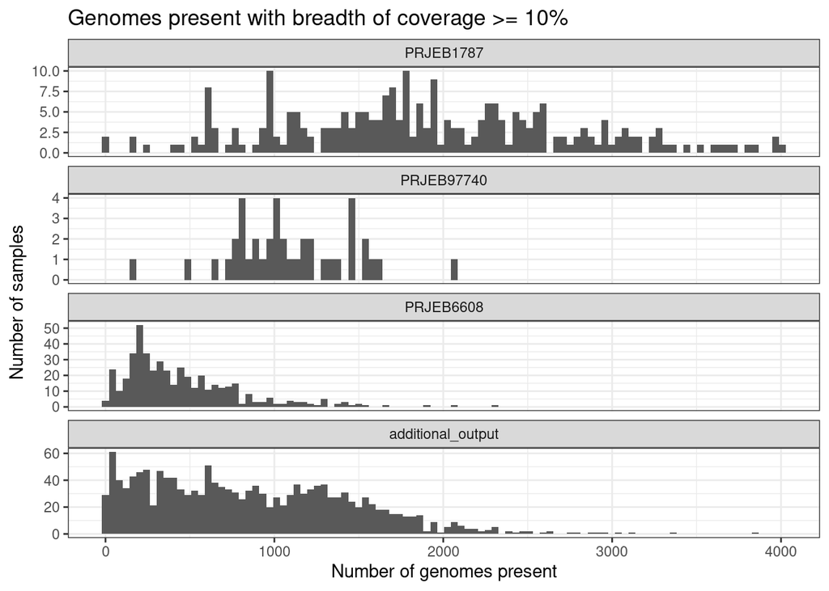

```r
num_genomes_per_sample0.1 <- aggregate(present0.1 ~ mgs_sample + bioproject, data = combined, FUN = sum)

ggplot(data = num_genomes_per_sample0.1, aes(x = present0.1)) +
  geom_histogram(bins = 100) +
  labs(x = 'Number of genomes present', y = 'Number of samples') +
  ggtitle('Genomes present with breadth of coverage >= 10%') +
  theme_bw() +
  facet_wrap(. ~ bioproject, ncol = 1, scales = 'free_y')
```

### Presence at 30% breadth

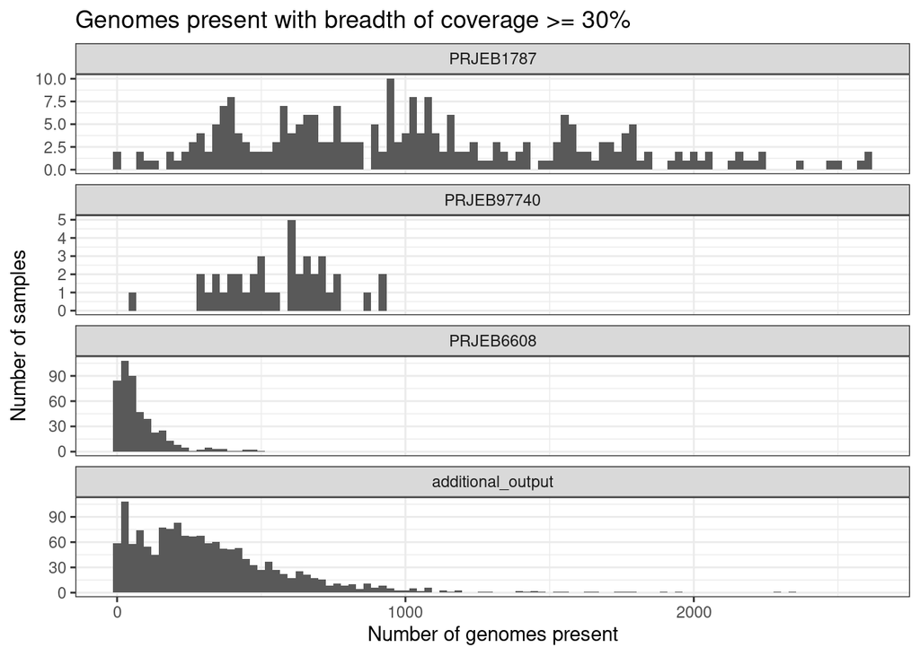

```r
num_genomes_per_sample0.3 <- aggregate(present0.3 ~ mgs_sample + bioproject, data = combined, FUN = sum)

ggplot(data = num_genomes_per_sample0.3, aes(x = present0.3)) +
  geom_histogram(bins = 100) +
  labs(x = 'Number of genomes present', y = 'Number of samples') +
  ggtitle('Genomes present with breadth of coverage >= 30%') +
  theme_bw() +
  facet_wrap(. ~ bioproject, ncol = 1, scales = 'free_y')
```

### Presence at 50% breadth

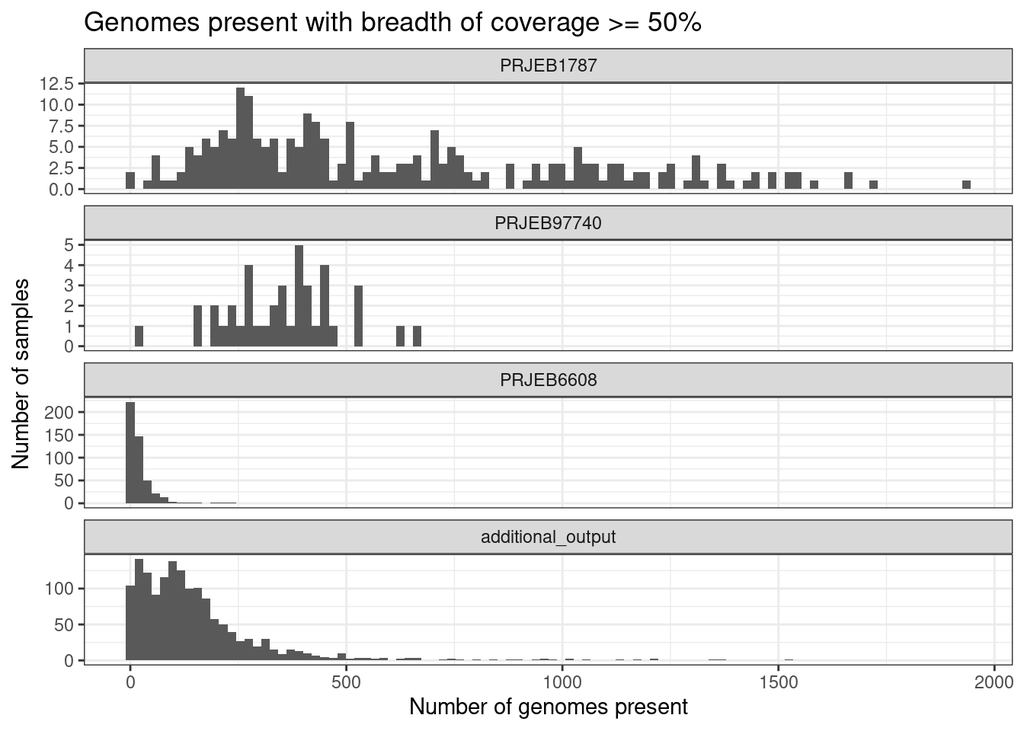

```r
num_genomes_per_sample0.5 <- aggregate(present0.5 ~ mgs_sample + bioproject, data = combined, FUN = sum)

ggplot(data = num_genomes_per_sample0.5, aes(x = present0.5)) +
  geom_histogram(bins = 100) +
  labs(x = 'Number of genomes present', y = 'Number of samples') +
  ggtitle('Genomes present with breadth of coverage >= 50%') +
  theme_bw() +
  facet_wrap(. ~ bioproject, ncol = 1, scales = 'free_y')
```

### Presence at 75% breadth

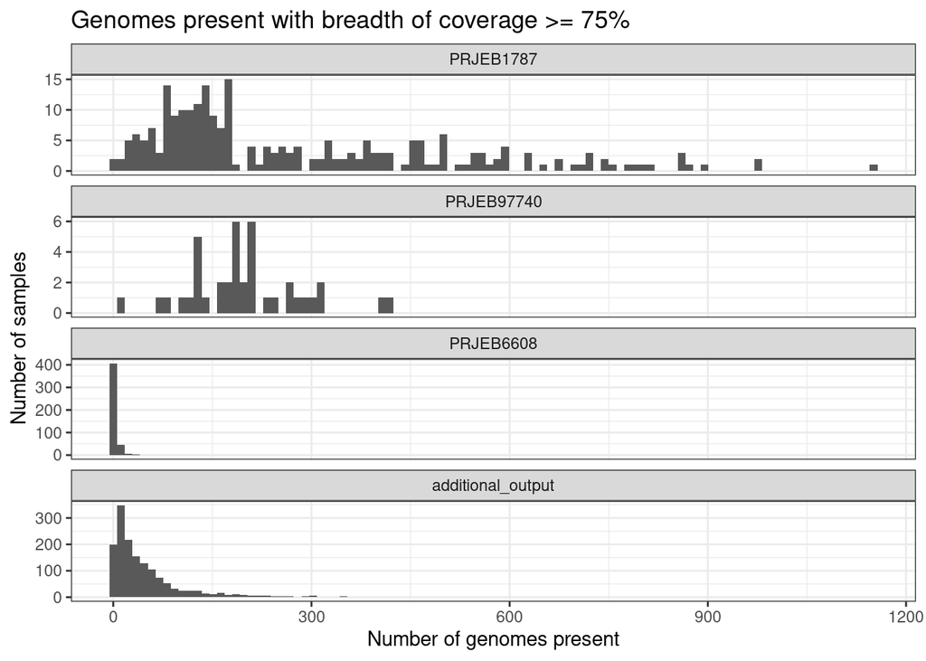

```r
num_genomes_per_sample0.75 <- aggregate(present0.75 ~ mgs_sample + bioproject, data = combined, FUN = sum)

ggplot(data = num_genomes_per_sample0.75, aes(x = present0.75)) +
  geom_histogram(bins = 100) +
  labs(x = 'Number of genomes present', y = 'Number of samples') +
  ggtitle('Genomes present with breadth of coverage >= 75%') +
  theme_bw() +
  facet_wrap(. ~ bioproject, ncol = 1, scales = 'free_y')
```

## Mean number of genomes per sample across continuous cut-offs

```r
all_breadth_mean_num <- list()

breadth_cutoffs <- seq(0.01, 1, 0.01)

for (bioproject in bioprojects) {
  combined_bioproject <- combined[which(combined$bioproject == bioproject), ]

  present_out <- mclapply(breadth_cutoffs,
                          function(cutoff) {
    tmp <- combined_bioproject
    tmp$cutoff <- ifelse(tmp$breadth > cutoff, 1, 0)
    mean_per_sample <- aggregate(cutoff ~ mgs_sample, data = tmp, FUN = sum)
    return(mean(mean_per_sample$cutoff))
  },
  mc.cores = 64)

  all_breadth_mean_num[[bioproject]] <- data.frame(Cutoff = breadth_cutoffs,
                                                   Mean_genomes_per_sample = sapply(present_out,
                                                                                    function(x) { x[[1]]}))
}
```

Try breadth of coverage cut-offs from 1% to 100% in 1% increments

### PRJEB1787

```r
PRJEB1787_elbow_i <- pathviewr::find_curve_elbow(all_breadth_mean_num[["PRJEB1787"]])

ggplot(data =  all_breadth_mean_num[["PRJEB1787"]], aes(x = Cutoff, y = Mean_genomes_per_sample)) +
    geom_point(color = "black", size = 0.5) +
    labs(x = 'Breadth of coverage cutoff', y = 'Mean number of genomes per sample') +
    ggtitle('Mean number of genomes per sample across breadth of coverage cutoffs') +
    theme_bw() +
  geom_vline(xintercept = all_breadth_mean_num[["PRJEB1787"]]$Cutoff[PRJEB1787_elbow_i],
             linetype = 'dashed', col = "red")
```

[output not shown]

Elbow cut-off determined to be 0.18

### PRJEB97740

```r
PRJEB97740_elbow_i <- pathviewr::find_curve_elbow(all_breadth_mean_num[["PRJEB97740"]])

ggplot(data =  all_breadth_mean_num[["PRJEB97740"]], aes(x = Cutoff, y = Mean_genomes_per_sample)) +
    geom_point(color = 'black', size = 0.5) +
    labs(x = 'Breadth of coverage cutoff', y = 'Mean number of genomes per sample') +
    ggtitle('Mean number of genomes per sample across breadth of coverage cutoffs') +
    theme_bw() +
  geom_vline(xintercept = all_breadth_mean_num[["PRJEB97740"]]$Cutoff[PRJEB97740_elbow_i],
             linetype = 'dashed', col = "red")
```

[output not shown]

Elbow cut-off determined to be 0.18

### PRJEB6608

```r
PRJEB6608_elbow_i <- pathviewr::find_curve_elbow(all_breadth_mean_num[["PRJEB6608"]])

ggplot(data =  all_breadth_mean_num[["PRJEB6608"]], aes(x = Cutoff, y = Mean_genomes_per_sample)) +
    geom_point(color = 'black', size = 0.5) +
    labs(x = 'Breadth of coverage cutoff', y = 'Mean number of genomes per sample') +
    ggtitle('Mean number of genomes per sample across breadth of coverage cutoffs') +
    theme_bw() +
  geom_vline(xintercept = all_breadth_mean_num[["PRJEB6608"]]$Cutoff[PRJEB6608_elbow_i],
             linetype = 'dashed', col = "red")
```

[output not shown]

### additional_output

```r
additional_output_elbow_i <- pathviewr::find_curve_elbow(all_breadth_mean_num[["additional_output"]])

ggplot(data =  all_breadth_mean_num[["additional_output"]], aes(x = Cutoff, y = Mean_genomes_per_sample)) +
    geom_point(color = 'black', size = 0.5) +
    labs(x = 'Breadth of coverage cutoff', y = 'Mean number of genomes per sample') +
    ggtitle('Mean number of genomes per sample across breadth of coverage cutoffs') +
    theme_bw() +
  geom_vline(xintercept = all_breadth_mean_num[["additional_output"]]$Cutoff[additional_output_elbow_i],
             linetype = 'dashed', col = "red")
```

[output not shown]

Elbow cut-off determined to be 0.18

# Investigate within-species interference

We are concerned that strains of the same species might share too much sequence similarity so that mapping could not be performed.

```r
taxa_map <- read.table('/mfs/gdouglas/projects/ocean_mags/mapfiles/MAG_taxa_breakdown.tsv.gz',
                       header = TRUE, sep = '\t', stringsAsFactors = FALSE, row.names = 2)

species_tallies <- table(taxa_map$Species)
species_breakdown <- data.frame(count = as.integer(species_tallies))
rownames(species_breakdown) <- names(species_tallies)

combined$species <- taxa_map[combined$genome, 'Species']

# Only consider species that are classified.
classified_species <- unique(grep("s__$", rownames(species_breakdown), invert = TRUE, value = TRUE))

classified_species_w_multi_genomes <- intersect(rownames(species_breakdown)[which(species_breakdown$count >= 2)], classified_species)

species_breakdown_classified <- species_breakdown[classified_species, , drop = FALSE]
```

The below analyses focus on the 2482 unique species that are classified at the species level.

## Number of genomes per species

Summary of the mean number of genomes per classified species.

```r
summary(species_breakdown_classified$count)
```

```
##    Min. 1st Qu.  Median    Mean 3rd Qu.    Max.
##    1.00    1.00    2.00    3.71    4.00  150.00
```

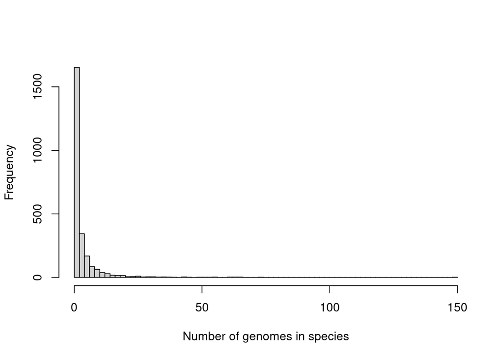

```r
hist(species_breakdown_classified$count, breaks = 100, main = "", xlab = "Number of genomes in species")
```

## Number of genomes within species vs. max breadth

Dig into whether the number of genomes per species is negatively associated with the max breadth (which you might expect if there is too much mapping competition).

Restricted to genome/sample combinations with breadth >= 10%.

Fortunately this bias is not observed!

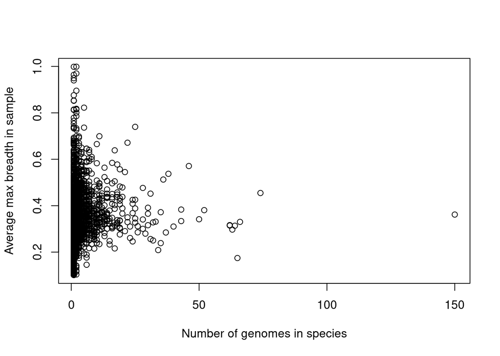

```r
combined_above0.1 <- combined[which(combined$breadth > 0.1), ]
combined_above0.1_max_per_species_sample <- aggregate(breadth ~ mgs_sample + species, data = combined_above0.1, FUN = max)
combined_above0.1_max_per_averaged <- aggregate(breadth ~ species, data = combined_above0.1_max_per_species_sample, FUN = mean)

# Add numbers of genomes in each species.
combined_above0.1_max_per_averaged$species_count <- species_breakdown[combined_above0.1_max_per_averaged$species, 'count']

combined_above0.1_max_per_averaged <- combined_above0.1_max_per_averaged[which(combined_above0.1_max_per_averaged$species %in% classified_species), ]

plot(combined_above0.1_max_per_averaged$species_count, combined_above0.1_max_per_averaged$breadth,
     xlab="Number of genomes in species",
     ylab="Average max breadth in sample")
```

```r
cor.test(combined_above0.1_max_per_averaged$species_count, combined_above0.1_max_per_averaged$breadth)
```

```
##
##  Pearson's product-moment correlation
##
## data:  combined_above0.1_max_per_averaged$species_count and combined_above0.1_max_per_averaged$breadth
## t = 2.2151, df = 1986, p-value = 0.02687
## alternative hypothesis: true correlation is not equal to 0
## 95 percent confidence interval:
##  0.005692743 0.093402569
## sample estimates:
##        cor
## 0.04964337
```

## Prevalence of different strains/MAGs within same species

Compare spread of max breadth values across all genomes within the same species. Hopefully there won’t be a huge difference overall (as you would hope that all MAGs are clearly present at least once).

Only consider classified species with at least two genomes, and considered species with > 30 and <= 30 genomes separately.

Based on this analysis, there are many cases where multiple genomes can be mapped to per species, so at least this is not a universal bias. There are also several cases where one genome or the overall species are not mapped to. It’s hard to know whether this is driven by biological factors or technical bias, but I think we should proceed with the data.

```r
combined_max_by_genome <- aggregate(breadth ~ genome + species, data = combined, FUN = max)
combined_max_by_genome <- combined_max_by_genome[which(combined_max_by_genome$species %in% classified_species_w_multi_genomes), ]

combined_max_by_genome_species_max <- aggregate(breadth ~ species, data = combined_max_by_genome, FUN = max)
combined_max_by_genome_species_min <- aggregate(breadth ~ species, data = combined_max_by_genome, FUN = min)

max_compare <- data.frame(species = combined_max_by_genome_species_max$species,
                          max_breadth = combined_max_by_genome_species_max$breadth,
                          min_breadth = NA,
                          genome_num = NA)

rownames(max_compare) <- max_compare$species
rownames(combined_max_by_genome_species_min) <- combined_max_by_genome_species_min$species
max_compare$min_breadth <- combined_max_by_genome_species_min[rownames(max_compare), "breadth"]

max_compare$genome_num <- species_breakdown[max_compare$species, "count"]
```

### <= 30 genomes per species

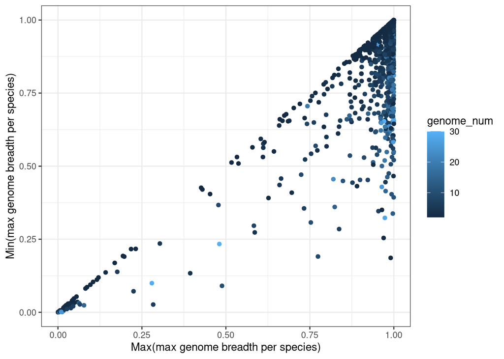

```r
ggplot(data = max_compare[which(max_compare$genome_num <= 30), ], aes(x = max_breadth, y = min_breadth, colour = genome_num)) +
         geom_point() +
  theme_bw() +
     xlab("Max(max genome breadth per species)") +
     ylab("Min(max genome breadth per species)")
```

### > 30 genomes per species

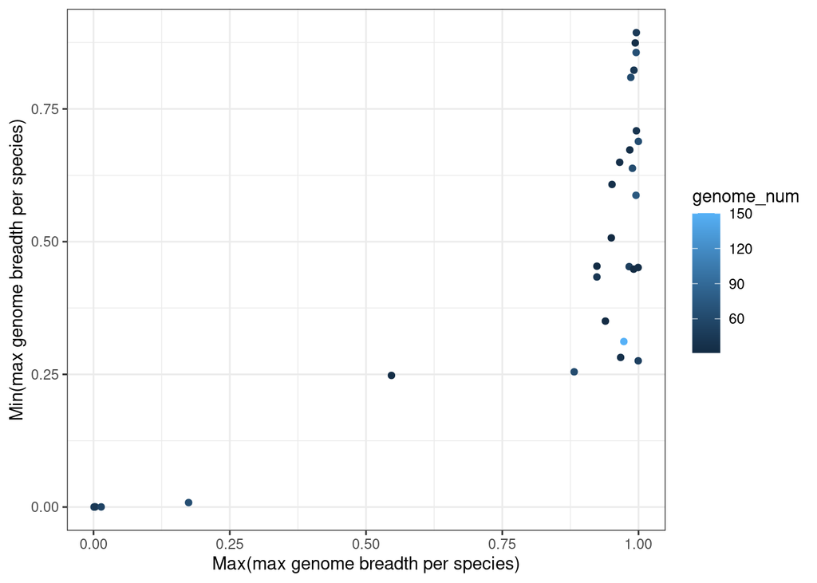

```r
ggplot(data = max_compare[which(max_compare$genome_num > 30), ], aes(x = max_breadth, y = min_breadth, colour = genome_num)) +
         geom_point() +
  theme_bw() +
     xlab("Max(max genome breadth per species)") +
     ylab("Min(max genome breadth per species)")
```